# Undergraduate Dissertation: The effects of armed conflict characteristics on the provision of external support

Student ID: 11004503

2025-02-26

# Title Page

## Declaration and Copyright statement

### Dissertation Declaration

This work is all the author’s original work unless referenced clearly to the contrary. No portion of the work referred to in the dissertation has been submitted in support of an application for another degree or qualification of this or any other university or other institute of learning.

### Dissertation Intellectual Property Statement

The author of this dissertation (including any appendices and/or schedules to this dissertation) owns certain copyright or related rights in it (the “Copyright”) and she has given The University of Manchester certain rights to use such Copyright, including for administrative purposes.

1. Copies of this dissertation, either in full or in extracts and whether in hard or electronic copy, may be made only in accordance with the Copyright, Designs and Patents Act 1988 (as amended) and regulations issued under it or, where appropriate, in accordance with licensing agreements which the University has entered into. This page must form part of any such copies made.
2. The ownership of certain Copyright, patents, designs, trademarks and other intellectual property (the “Intellectual Property”) and any reproductions of copyright works in the dissertation, for example graphs and tables (“Reproductions”), which may be described in this dissertation, may not be owned by the author and may be owned by third parties. Such Intellectual Property and Reproductions cannot and must not be made available for use without the prior written permission of the owner(s) of the relevant Intellectual Property and/or Reproductions.
3. Further information on the conditions under which disclosure, publication and commercialisation of this dissertation, the Copyright and any Intellectual Property and/or Reproductions described in it may take place is available in the University IP Policy, in any relevant Dissertation restriction declarations deposited in the University Library, and The University Library’s regulations.

## Abstract

All analyses were conducted in R (R Core Team, 2024), with the analytic code and input data made publicly available on GitHub to ensure transparency and facilitate replication.

## Introduction

Despite a reduction in conflicts and deaths, the past decade remains the most violent on record (Engström, Pettersson, and Öberg, 2024). Discussions around armed conflicts and external support have once again become extremely relevant to the political context and international relations, with the USA withdrawing large means of their military and financial support to Ukraine and many other geopolitical tensions and conflicts ongoing. Not only do these developments raise questions around the responsibility to and the sustainability of support but further around the future of military alliances and combined defence efforts such as NATO. Today, although conflicts are largely fought by developing nations, they rely heavily on advanced military equipment produced by industrial countries, further reinforcing military over social investments (Sivard, 1996). The prevalence and complexity of external support in armed conflicts have grown significantly over the past decades. From 1975 to 2017, 80% of intrastate conflicts involved at least one instance of external support, with state actors being the predominant supporters (Meier et al., 2023). Recent years have seen systemic shifts in external support, characterised by the rise of multilateral coalitions and collaborative interventions. Nearly one-third of all support instances now involve such coalitions, emphasising burden-sharing and legitimacy (Meier et al., 2023). This raises questions around the responsibility and accountability of external supporters, especially when military actions turn into war crimes.

While extremely timely, Criminology has historically neglected armed conflict (Hagan, 2015; Jamieson, 2003; Ruggiero, 2015; Walklate and McGarry, 2015), let alone external support. But even in research on external support, the content of interventions remains underexplored, despite its impact on conflict trajectories. Differentiating between support types - military training, material aid, or safe havens - can highlight distinct effects on outcomes (Roberts, 2019).

This research adopts an interdisciplinary approach, integrating Criminology, Peace and Conflict Studies, and Economics to examine whether conflict characteristics affect the provision of external support and identify trends and conditions under which external support is provided. By distinguishing between support types, it aims to provide a more robust understanding of the role of external supporters and their motives, essential for further discussions around liability and responsibility. In doing so, it bridges critical gaps in Criminology, contributing to a more comprehensive understanding of the interplay between external interventions and conflict dynamics.

## Literature Review

The landscape of armed conflict has shifted in recent decades, with a rise in internationalised intrastate conflicts where external states support non-state actors opposing governments (Engström, Pettersson, and Öberg, 2024). Armed conflict herein is defined as ‘a contested incompatibility that concerns government and/or territory where the use of armed force between two parties, of which at least one is the government of a state, results in at least 25 battle-related deaths in a calendar year’ (Themner, 2017, p.2). The primary parties in such conflicts include governments, which control the state capital, and opposition organisations, which are formally organised groups using armed force to influence the outcome of the incompatibility.

Although developing nations fight most of today’s conflicts, they are often fought with weapons from industrialised countries, reflecting 20th-century technological advancements (Sivard, 1996). As geopolitical tensions rise, the role of external support in these conflicts has become a central topic of discussion (Ayiar et al., 2023; Federle et al., 2024). External support, defined as militarily relevant assistance provided by outside parties to active conflicts, is distinct from peacetime activities like arms trade or security reforms (Meier et al., 2023; Meier, 2022). This support aims to enhance the recipient’s military capabilities and is provided with the clear intent of facilitating military victory over the opposing side. It includes materiel, knowledge, or services directly aiding warfare but excludes unintentional support (e.g., due to state weakness) and indirect measures like sanctions. Additionally, diplomatic efforts, humanitarian aid, and mediation offers do not qualify as external support since they do not directly contribute to the military outcome. The external nature of support is determined by whether the provider is not a primary warring party in the conflict, even if present in the same territory.

Foreign military operations, though a small portion of defence spending, are pivotal in defining international relations and interventions (Marín, 2021). Understanding why and how states intervene and the consequences of different types of support is vital to analysing external involvement. The interplay between conflict characteristics and external support is complex, with interventions - whether direct military actions or indirect aid - often prolonging hostilities and complicating peace efforts. This research seeks to explore these themes, examining how conflict characteristics shape external interventions.

### Armed conflicts in the social sciences

Armed conflict remains a pervasive yet underexplored subject in the social sciences, despite its profound historical and societal impact. Following the so-called ‘century of peace’ (1815–1914), war violence has persisted across continents, yet sociological inquiry has failed to match its prevalence or significance. States, through their ‘legitimate monopoly of violence’ (Weber, 1919 in McGarry and Walklate, 2019), justify violence via bureaucratic rationality, framing war as a noble endeavour to solidify authority and autonomy (Malešević, 2010a in McGarry and Walklate, 2019). Internationally, economic imperatives often guide responses to war, reducing it to a developmental obstacle, while historically, war was driven by imperial capitalist expansion (Ruggiero, 2023; Bonger, 1916 in McGarry and Walklate, 2019). Ethical frameworks further complicate the discourse, distinguishing ‘unjust’ wars, violating global peace, from ‘just’ wars perceived as punishment (Sutherland, 1942 in McGarry and Walklate, 2019), highlighting the contested morality surrounding armed conflict.

### Criminological theories on armed conflicts

Criminology has historically neglected armed conflict, despite its relevance to violence, victimisation, and state power (Hagan, 2015; Jamieson, 2003; Ruggiero, 2015; Walklate and McGarry, 2015). Critical criminologists view war as a form of state crime legitimised by dominant powers who shape international norms to justify past and future conflicts (Kramer and Michalowski, 2005; Bonanate, 2011 in Ruggiero, 2023). War is intertwined with the political economy and often rooted in capitalism, which fuels conflicts through profit-driven globalisation (Bonger, 1916 in McGarry and Walklate, 2018; Klein, 2011). This global economic system blurs lines between legitimate and harmful actions, exacerbating violence (Ruggiero, 2005).

Despite millions of ‘legitimate’ killings in war, criminology has been reluctant to challenge the legitimacy of such violence or address its broader systemic causes (Ruggiero, 2005). Wartime atrocities are reframed as patriotic acts, aligning with state narratives through techniques of neutralisation (Sykes and Matza, 1957; Ruggiero, 2005). Examining external conflict support raises critical questions about complicity, liability for war crimes, and whether such support escalates violence or fosters peace. These dynamics underscore the importance of rethinking state authority, as legality and illegality are often strategically maneuvered in the pursuit of power (Heyman, 1999 in Ruggiero, 2005). As war weakens social bonds, fosters disorganisation, and perpetuates cycles of violence, criminologists have a unique opportunity to address its multifaceted impacts and advocate for systemic reforms, including peaceful conflict resolution and global resource redistribution (Jamieson, 1998; Ruggiero, 2005).

#### Hot and cold wars: The evolution of armed conflict

Criminological genocide studies distinguish between ‘hot’ and ‘cold’ acts of mass violence (Rafter, 2016), reflecting the emotional dynamics that drive mass violence. “Hot” genocides are characterised by forward panic (Collins in Rafter, 2016), a highly aroused emotional state where prolonged tension and fear suddenly erupt into explosive violence. This emotional rush carries perpetrators into a cycle of aggression, elation, and hysteria, often leading to actions they would not commit in calmer moments. Mass violence tends to escalate when strong emotional momentum is achieved. However, not all genocides are driven by intense emotions — some unfold in a more calculated, bureaucratic manner, devoid of immediate emotional frenzy. In reality, genocides are not purely ‘hot’ or ‘cold’ but may fluctuate between these emotional states over time. This study attempts to apply this concept to the provision of external support in armed conflicts, exploring whether external support is correlated with conflict characteristics and might thereby be determined to be a calculated, rational choice. Such analysis can shed light on the emotional and strategic dynamics of external support, offering insights into the motives and strategies of intervention.

### The economic cost of conflict and mass violence

#### The effects of armed conflicts on the conflict parties

War and armed conflict profoundly impact parties involved, with ordinary civilians disproportionately suffering due to fatalities, displacement, and long-term public health crises from destroyed infrastructure (Hoeffler and Reynal-Querol, 2003). War-torn countries face reduced growth, higher poverty rates, and weakened institutions, with recovery dependent on robust policy reforms (Hoeffler and Reynal-Querol, 2003). High-intensity violence during conflicts lowers economic growth, life expectancy, and educational attainment, with these effects often persisting long-term (Le, Bui, and Uddin, 2022). Increased military spending further distorts government budgets, diverting resources from critical public goods like healthcare and education (Hoeffler and Reynal-Querol, 2003).

However, economic impacts vary by context. Domestic wars typically reduce growth, while wars fought abroad can stimulate mild economic expansion through increased military spending and investments in related sectors (Federle et al., 2024; Chupilkin and Kóczán, 2022). War economies sometimes exhibit resilience, particularly in developed states where increased labour and capital utilisation mitigate conflict’s effects (Rasler and Thompson, 1985). Nonetheless, countries experiencing war on their territory often face catastrophic economic fallout, with non-initiators and losers suffering the largest GDP declines (Chupilkin and Kóczán, 2022). The enduring economic and social costs of war underscore its profoundly criminogenic nature.

#### The effects of armed conflicts on other countries

Wars and armed conflicts generate significant spillover effects, with severity influenced by geographic proximity and economic ties to the conflict zone. Neighbouring countries often face adverse economic consequences, while distant nations experience milder effects due to limited trade links and geographic distance (Federle et al., 2024). Weak trade integration can shield distant countries from severe supply shocks, and increased military spending may even stimulate economic activity in specific sectors (Federle et al., 2024). However, regions with stronger economic ties to the conflict zone experience amplified negative impacts, including disrupted stability and heightened uncertainty (Fang et al., 2020; Le, Bui, and Uddin, 2022). While inflation and output remain stable in distant countries, the ripple effects of war challenge interconnected global economies, highlighting the complex dynamics between conflict and economic stability (Federle et al., 2024).

### External support to armed conflicts

Research on external support in armed conflicts highlights its significant impact on conflict dynamics and outcomes. External actors, including state and non-state supporters, play pivotal roles by shaping conflict processes through diverse forms of assistance, such as military training and direct intervention (Gleditsch, 2007; Salehyan, 2010; Toukan, 2019).

The type and target of external support often align with intervening parties’ strategic interests. Governments typically receive training and troop assistance, while rebel groups rely on material aid, including light weaponry and technical expertise (Meier et al., 2023; Berlin and Malone, 2023). Rebel sponsorship is more common when governments also receive support, reflecting the interconnected nature of interventions (Salehyan et al., 2011). Nonetheless, support dynamics vary by conflict intensity, geographic proximity, and the relative strength of involved parties. Rebel groups seen as either too strong or too weak are less likely to attract aid due to their perceived ability to succeed or fail independently (Salehyan, Gleditsch, and Cunningham, 2011). The Cold War intensified conflicts through superpower support, but its end shifted patterns, reducing insurgencies and prolongation, while rebel groups lost aid, leading many conflicts to peter out or end in settlements (Testerman, 2015; Kalyvas and Balcells, 2010 in Roberts, 2019).

Over recent decades, the number of actors providing external support has grown, despite only a slight rise in total conflicts (Meier et al., 2023). This proliferation adds veto players, complicating bargaining and potentially prolonging conflicts (Cunningham, 2010). By 2017, 77% of active conflict-dyads featured state support for governments alone, driven in part by the post-9/11 counterterrorism focus, which stigmatised support for non-state actors (Meier et al., 2023). Multilateral counter-extremism efforts, often led by UN Security Council members, have reinforced this trend (Meier et al., 2023).

*Direct military interventions have become the most common form of external support*, with intervening states increasingly opting to deploy their own troops rather than solely providing equipment and training (Meier et al., 2023). This shift reflects a broader trend toward intensive engagement strategies, particularly among external states with significant stakes in conflict outcomes. While foreign troops are deployed in less than 20% of conflicts, they are often associated with heavy force models, including strategic bombing and civilian protection (Sullivan and Karreth, 2019). *Training and expertise remain the most frequent forms of support*, while material aid dominates assistance to rebel groups (Meier et al., 2023; Berlin and Malone, 2023). States that sponsor armed groups tend to back multiple organisations, with an average of 10.36 groups supported per state (Berlin and Malone, 2023).

The internationalisation of intrastate conflicts highlights notable trends. While troop support has declined, the total number of external interventions continues to grow, reflecting persistent interest in shaping conflict trajectories through both direct and indirect means (Engström, Pettersson, and Öberg, 2024; Chang and Sellak, 2022). These evolving dynamics underscore external support’s dual role as both an escalatory factor and a mechanism for resolution, offering critical insights for modern conflict management.

#### Why external supporters get involved

External supporters engage in civil conflicts for diverse and strategic reasons, including geopolitical, economic, and ideological motives, as well as specific foreign policy objectives (Findlay and Teo, 2006; Meier et al., 2023). Economic interests often drive involvement, with external powers seeking to protect trade benefits or access resources by backing domestic victors (Regan, 1998; Kathman, 2011). In some instances, involvement appears benevolent, such as facilitating peace talks (Bhattarai, 2016). However, third-party intervention is rarely altruistic; states often aim to weaken adversaries, prevent conflict spillover, or maintain influence in post-colonial regions (Cunningham, 2010; Gregory, 2000).

Shared ethnic or ideological ties between sponsors and armed groups are among the strongest predictors of external support (Salehyan, Gleditsch, and Cunningham, 2011; Sozer, 2016). These connections signal shared goals and reduce the risk that resources will be misused (Berlin and Malone, 2023; Salehyan, 2010). Common cultural or ideological ground facilitates communication and enhances trust, improving cooperation (San Akca, 2016; Bacon, 2018). Democratic states often support each other in combating rebels, reflecting shared values and interests in stability (Goldman and Abulof, 2016). However, relying on such ties can oversimplify sponsorship decisions, especially in contexts with multiple potential recipients or competing priorities (Berlin and Malone, 2023).

Strategically, sponsoring militant groups enables states to destabilise rivals or gain leverage without direct conflict. Delegating violence minimises costs while exploiting the instability inflicted on adversaries (Schultz, 2010; Bapat, 2011). However, this approach carries risks, including retaliation, escalation, and the possibility that armed groups will pursue independent agendas (Schultz, 2010; Maoz and San Akca, 2012). Ultimately, external support is a calculated foreign policy tool used to influence conflict outcomes while advancing sponsors’ strategic goals.

#### The effects of external support on conflicts

External support profoundly influences armed conflict, shaping its onset (Cunningham, 2016; Regan and Meachum, 2014), duration (Aydin and Regan, 2011; Anderson, 2019), outcomes (Sawyer, Cunningham and Reed, 2017), and recurrence (Karlén, 2017). Many contemporary conflicts are recurrences of previous ones, particularly territorial disputes, which are prone to persistence due to entrenched incompatibilities (Quinn, Mason, and Gurses, 2007). In such cases, external support is often limited, as most states favour preserving territorial status quos.

Interventions, whether direct (troops) or indirect (weapons, logistics, training), frequently prolong conflicts by altering the cost-benefit calculations of belligerents (Fearon, in Testerman, 2015; Lacina, 2006). Although external aid can alter power dynamics, it frequently intensifies conflicts, complicates negotiations, and reduces the likelihood of peaceful resolutions (Olson Lounsbery, 2016). It also internationalises conflicts, introducing new veto players and complicating bargaining dynamics (Zartman, 1992 in Saideman, 2002; Salehyan, Gleditsch, and Cunningham, 2011). When foreign states support rebel groups, they not only supply material resources but also confer political legitimacy, further complicating resolution efforts and prolonging violence (Petrova, 2019).

External support’s impact extends to post-conflict dynamics. Rebel groups with sustained backing are more likely to remobilise, anticipating future assistance, thereby increasing conflict recurrence (Karlén, 2017). Although external support can improve the odds of military victory (Balch-Lindsay et al., 2008), it often exacerbates humanitarian crises, with rebels exploiting moral hazards to attract further intervention (Rauchhaus, 2009). Thus, while external support can alter power dynamics and sustain resistance, it frequently intensifies violence, complicates negotiations, and reduces the chances of a peaceful resolution, underscoring its complex and paradoxical role in armed conflicts.

#### Limitations of past research

The study of external support in armed conflicts has provided critical insights but is hindered by several limitations. Much research focuses predominantly on support for non-state armed groups, particularly rebel organisations, sidelining other actors and minor armed engagements (Walter, 2004; Quinn, Mason, and Gurses, 2007). Additionally, studies often emphasise the initial decision to delegate support (Salehyan, 2010; San-Akca, 2016), neglecting how support dynamics evolve throughout a conflict’s lifecycle and the strategic factors influencing its continuation or cessation (Karlén, 2019; Tokdemir et al., 2021).

The content of interventions remains underexplored, despite its impact on conflict trajectories. Differentiating between support types - military training, material aid, or safe havens - can highlight distinct effects on outcomes (Roberts, 2019). Furthermore, the multi-actor dimension of support is frequently overlooked, despite evidence that sponsors selectively support specific groups within fragmented conflicts (Berlin and Malone, 2023).

A focus on rebel groups introduces methodological challenges and selection bias, limiting generalisability to other armed organisations (Abrahms, Ward, and Kennedy, 2018; Phillips, 2019). This neglect obscures patterns of external support across diverse settings, undermining frameworks linking organisational attributes to state sponsorship. Moreover, qualitative approaches dominate the literature, often at the expense of quantitative or mixed-method analyses better suited to capturing temporal and contextual variations in support dynamics (Petrova, 2019).

## Methodology

### Research Hypotheses

The study aims to test several hypotheses regarding the relationship between conflict characteristics and external support. These hypotheses are grouped based on the type of relationship they examine, focusing on whether conflict characteristics influence the provision of external support, the form of support provided, and the impact of support coalitions on the type of assistance.

##### Hypothesis Group 1: Conflict Characteristics affect whether external support is provided to a conflict party.

1. Conflict intensity affects whether external support is provided.
2. Conflict incompatibility affects whether external support is provided
3. The cumulative duration of conflict affects whether external support is provided.
4. The type of conflict affects whether external support is provided.
5. The region where the state conflict party is located affects whether external support is provided.
6. Whether a conflict is taking place before or after 9/11 affects whether external support is provided.
7. Whether a conflict is taking place during or after the Cold War affects whether external support is provided.

##### Hypothesis Group 2: Conflict characteristics influence what kind of external support is provided.

1. Conflict intensity affects what kind of external support is provided.
2. Conflict incompatibility affects what kind of external support is provided.
3. The cumulative duration of conflict affects what kind of external support is provided.
4. The type of conflict affects what kind of external support is provided.
5. The region where the state conflict party is located affects what kind of external support is provided.
6. Whether a conflict is taking place before or after 9/11 affects what kind of external support is provided.
7. Whether a conflict is taking place during or after the Cold War affects what kind of external support is provided.

##### Hypothesis 3: Whether support is provided in a coalition or as bilateral support affects what kind of external support is provided.

### Research Design

#### Data and operationalisation

This study draws on two key datasets from the Uppsala Conflict Data Program (UCDP): the UCDP Dyadic dataset (Version 18.1) (Harbom, et al., 2008; Eck and Pettersson, 2018) and the UCDP External Support dataset (ESD) (Version 18.1) (Meier et al., 2022). The UCDP Dyadic dataset provides data on armed conflicts, focusing on dyads — pairs of primary warring parties — and spans the years from 1946 to 2024, with the unit of analysis being the dyad-year. The dataset includes 2,935 observations across 25 variables, capturing various conflict characteristics such as the type of conflict, incompatibilities, and combatants. The ESD, covering the period from 1975 to 2017, focuses specifically on external support provided to conflict parties, detailing ten types of support such as military assistance, training, and funding. It offers 2,272 observations of 96 variables, coded from open-source material and subjected to intercoder reliability checks.

Its state-based armed conflict definition includes only incompatibilities concerning government and territory, potentially overlooking underlying causes. Additionally, conflicts that fail to meet the annual threshold of 25 battle-related deaths are missing, and cases where information on key variables such as incompatibility, actors, or intensity is uncertain are excluded. The datasets lack precise geographic data, instead assigning location based on the government side in a dyad rather than where the conflict occurs. This raises concerns about whether the ‘region’ variable used in the analysis accurately reflects the location of fighting.

The ESD further narrows the scope by only recording first-degree supporters - external actors directly assisting conflict parties - while ignoring second-degree supporters such as states providing logistical assistance or financial aid to regional coalitions (Meier, 2022). While differentiating between ten different kind of support, the categorisation of support types still simplifies complex interactions where states may provide multiple forms of aid over time. Additionally, non-state troop support is uniformly coded as zero, and support by international organisations, diaspora groups, private businesses, and religious institutions is excluded. Finally, the ESD’s threshold for recording assistance could lead to underreporting of minor interventions, which may affect the accuracy of support-related conclusions.

The study incorporates dependent, independent, and control variables (Table 1), categorised based on their measurement scales. All nominal independent variables were factorised to improve analytical clarity. The dependent variables measuring external support were expanded to differentiate between types of support (ext_category, ext_type) and their most frequent combinations (ext_combination). Conflict characteristics were kept as per their original categorisation, while cumulative duration was derived using a time-based formula.

Variable Table: Conflict Characteristics and External Support

| Category | Variable Name | Description | Measurement Scale |
| --- | --- | --- | --- |
| Dependent Variables |  |  |  |
|  | ext_sup | External support provided (1 = Yes) | Nominal |
|  | ext_x | Troop support (1 = Yes) | Nominal |
|  | ext_p | Foreign troop presence (1 = Yes) | Nominal |
|  | ext_y | Access to infrastructure/joint operations (1 = Yes) | Nominal |
|  | ext_w | Weapons support (1 = Yes) | Nominal |
|  | ext_m | Materiel and logistics support (1 = Yes) | Nominal |
|  | ext_t | Training and expertise support (1 = Yes) | Nominal |
|  | ext_f | Funding support (1 = Yes) | Nominal |
|  | ext_i | Intelligence support (1 = Yes) | Nominal |
|  | ext_l | Access to territory (1 = Yes) | Nominal |
|  | ext_o | Other support (1 = Yes) | Nominal |
|  | ext_u | Unknown support (1 = Yes) | Nominal |
|  | ext_category | Categorisation of the form of external support provided (i.e., whether no support, one individual form or several forms of support are provided) | Ordinal |
|  | ext_combination | Most common combinations of external support (up to three explicitly listed) | Nominal |
|  | ext_type | Categorisation of external support as direct, indirect, or no support | Nominal |
| Independent Variables |  |  |  |
|  | type | Type of conflict (1 = Extrasystemic, 2 = Interstate, 3 = Intrastate, 4 = Internationalized Intrastate) | Nominal |
|  | intensity | Conflict intensity (1 = Minor conflict, 2 = War) | Nominal |
|  | incompatibility | Conflict incompatibility (1 = Territory, 2 = Government, 3 = Both) | Nominal |
|  | cumulative_duration | Cumulative years of conflict (Years since first observed conflict year) | Ratio |
|  | region | Region of conflict (1 = Europe, 2 = Middle East, 3 = Asia, 4 = Africa, 5 = Americas) | Nominal |
| Control Variables |  |  |  |
|  | cold_war | Cold War status (0 = Cold War, 1 = Post-Cold War) | Nominal |
|  | nine_eleven | Period relative to 9/11 (0 = Before 9/11, 1 = After 9/11) | Nominal |
|  | ext_coalition | Coalition support (0 = Bilateral support, 1 = Coalition support) | Nominal |

### Data analysis

Descriptive statistical methods were employed to summarise and analyse the data. This included the calculation of total conflict counts per year, as well as the summarisation of conflict intensity and the mean and median conflict durations by region. These statistics were visualised through various graphical methods, such as stacked bar charts for conflict intensity levels and line plots for the evolution of external support types, thereby providing a clear depiction of temporal trends in conflict characteristics and support dynamics.

Fixed Effects Logistic Regression: log (provision of support/no provision of support) = α + ß1⋅incompatibility + ß2⋅type + ß3⋅intensity + ß4⋅region + ß5⋅duration + ß6⋅nine_eleven + ß7⋅cold_war + ß8⋅coalition_support + γdyad_id

Random Effects Logistic Regression: log (provision of support/no provision of support) = α + ß1⋅incompatibility + ß2⋅type + ß3⋅intensity + ß4⋅region + ß5⋅duration + ß6⋅nine_eleven + ß7⋅cold_war + ß8⋅coalition_support + udyad_id

## Findings

### Independent variables: Conflict characteristics

Although the total number of conflicts has decreased and minor armed conflicts make up the majority of armed conflicts, recent years have seen a rise in wars (Figure 2)

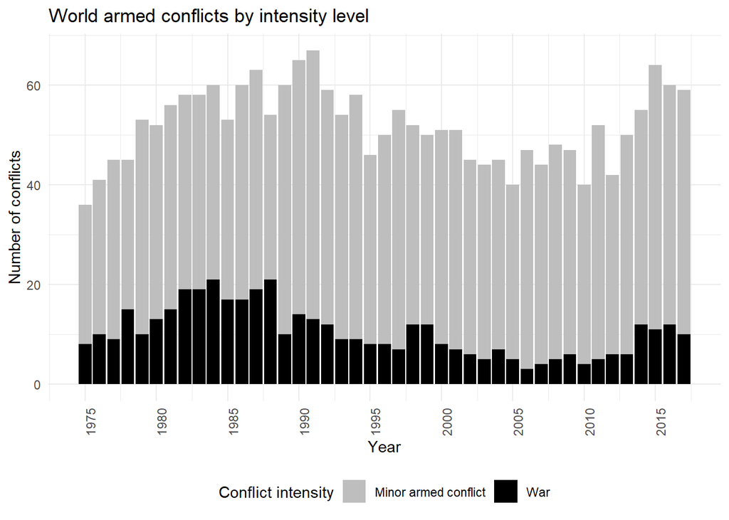

While most conflicts are fought in Asia and Africa, the number of conflicts fought in the Middle East is growing (Appendix 1). Especially conflicts in Asia and the Americas seem to be going on for a long time (Figure 3).

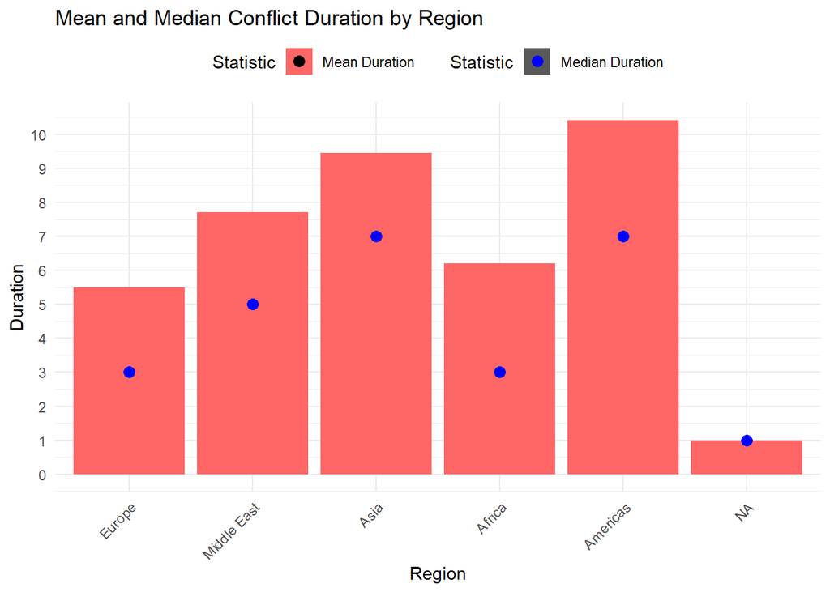

Intrastate conflicts are the most common type of conflict, followed by internationalised intrastate conflicts, whose number has been growing since the early 2000s (Appendix 2). While there is fluctuation between the incomptibility types ‘territory’ and ‘government’, most conflicts in 2017 were about territory (Appendix 3). Hardly any are about territory and government.

### Dependent variables: Provision of external support

The provision of external support has risen, with indirect support being the most common (Figure 4) and supporters providing three forms of support on average (Median: 4).

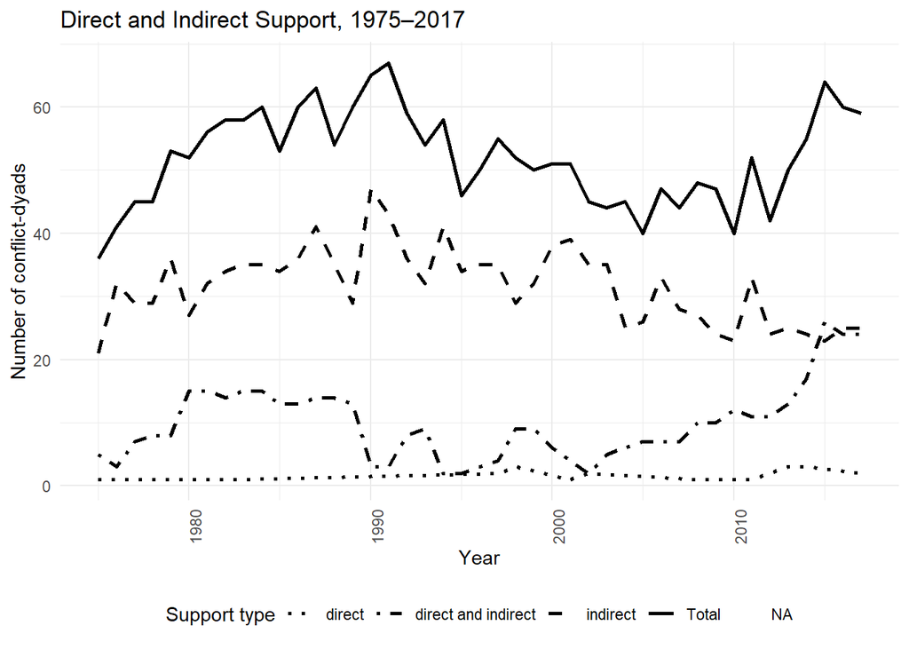

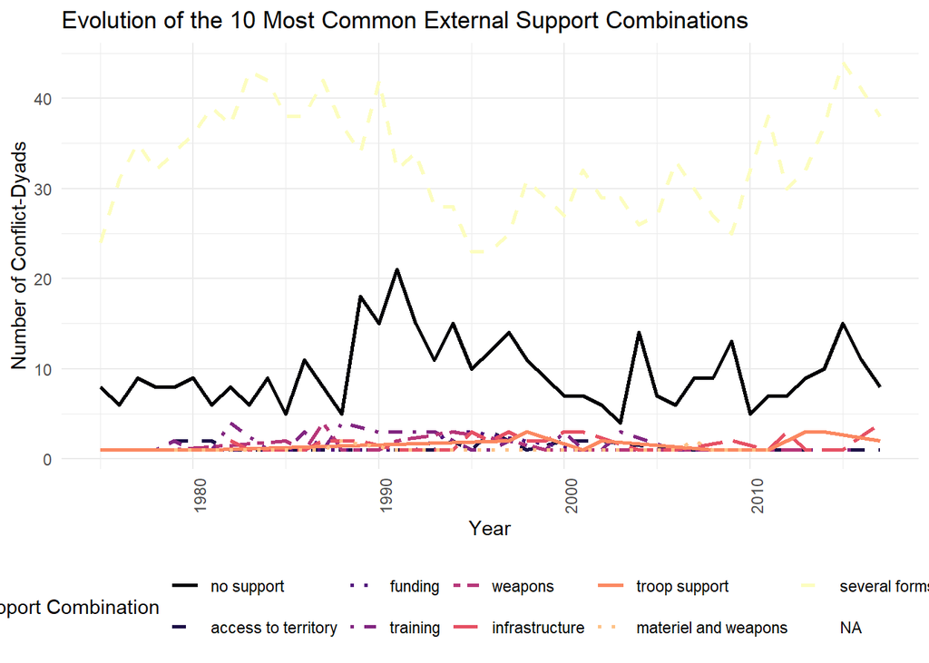

### Regression Analysis

The random effects model for the provision of external support (Table 2) shows no statistically significant results. However, the fixed effects model reveals that the correlation between internationalised intrastate conflicts, wars, and the post-Cold War period and the provision of external support are statistically significant.

|  | Troop support |  |  | Weapons |  |  | Intelligence |  |  |
| --- | --- | --- | --- | --- | --- | --- | --- | --- | --- |
| Predictors | Odds Ratios | CI | p | Odds Ratios | CI | p | Odds Ratios | CI | p |
| (Intercept) | Inf | 0.00 – Inf | 0.999 | 37.25 | 3.25 – 426.74 | **0.004** | 0.00 | 0.00 – 0.04 | **<0.001** |
| Incompatibility (government) | 0.09 | 0.00 – 548.88 | 0.589 | 1.59 | 0.52 – 4.84 | 0.415 | 0.16 | 0.05 – 0.56 | **0.004** |
| Incompatibility (territory and government) | 82361273346349836080288640846868066066646022402286860286020448044800.00 | 0.00 – Inf | 1.000 | 0.17 | 0.00 – 95.31 | 0.581 | 10.33 | 0.02 – 5795.01 | 0.470 |
| Type (interstate) | 0.09 | 0.00 – 6918144862350142572022820.00 | 0.937 | 0.61 | 0.03 – 13.89 | 0.755 | 0.88 | 0.04 – 19.85 | 0.934 |
| Type (internationalised intratstate) | 14.62 | 0.00 – 457471288737950976.00 | 0.890 | 2.14 | 0.99 – 4.64 | 0.053 | 1.92 | 0.82 – 4.51 | 0.133 |
| Intensity (war) | 36.12 | 0.00 – 22379768085.39 | 0.728 | 4.40 | 2.17 – 8.94 | **<0.001** | 0.45 | 0.23 – 0.88 | **0.020** |
| Region (Middle East) | 0.00 | 0.00 – Inf | 1.000 | 1.02 | 0.08 – 13.03 | 0.988 | 2.23 | 0.15 – 32.34 | 0.557 |
| Region (Asia) | 0.00 | 0.00 – Inf | 1.000 | 0.54 | 0.05 – 6.08 | 0.621 | 0.85 | 0.07 – 10.81 | 0.899 |
| Region (Africa) | 0.00 | 0.00 – Inf | 1.000 | 0.37 | 0.03 – 4.21 | 0.424 | 2.93 | 0.23 – 36.87 | 0.405 |
| Region (Americas) | 2544354097.14 | 0.00 – Inf | 1.000 | 0.12 | 0.01 – 2.93 | 0.194 | 61.62 | 2.15 – 1765.93 | **0.016** |
| Duration | 0.90 | 0.73 – 1.11 | 0.310 | 1.00 | 0.96 – 1.04 | 0.943 | 1.03 | 0.99 – 1.08 | 0.172 |
| After 9/11 | 0.19 | 0.01 – 4.74 | 0.309 | 2.29 | 1.05 – 4.98 | **0.037** | 11.13 | 4.86 – 25.53 | **<0.001** |
| Post-Cold War | 0.00 | 0.00 – Inf | 0.999 | 0.07 | 0.03 – 0.18 | **<0.001** | 4.91 | 1.77 – 13.63 | **0.002** |
| Coalition support | 48196678921778274108646202240828428484402264462284000484468820248648824868028000280088602088862460040064888486244644206024244624428266044008644642400044668622628246848808428208248840.00 | 0.00 – Inf | 1.000 | 0.47 | 0.15 – 1.43 | 0.181 | 2.93 | 0.91 – 9.42 | 0.071 |
| Random Effects |  |  |  |  |  |  |  |  |  |
| σ<sup>2</sup> | 3.29 |  |  | 3.29 |  |  | 3.29 |  |  |
| τ<sub>00</sub> | 34.56 <sub>dyad_id</sub> |  |  | 9.94 <sub>dyad_id</sub> |  |  | 10.79 <sub>dyad_id</sub> |  |  |
| ICC | 0.91 |  |  | 0.75 |  |  | 0.77 |  |  |
| N | 318 <sub>dyad_id</sub> |  |  | 318 <sub>dyad_id</sub> |  |  | 318 <sub>dyad_id</sub> |  |  |
| Observations | 1449 |  |  | 1449 |  |  | 1449 |  |  |
| Marginal R<sup>2</sup> / Conditional R<sup>2</sup> | 1.000 / 1.000 |  |  | 0.154 / 0.790 |  |  | 0.299 / 0.836 |  |  |

[output not shown]

|  | Troop support |  |  | Weapons | Intelligence |
| --- | --- | --- | --- | --- | --- |
| Predictors | Odds Ratios | CI | p |  |  |
| typeinternationalised intrastate | 0.00 | 0.00 – 0.00 | **0.002** |  |  |
| intensityWar | 36545612.46 | 175807.70 – 7596833151.99 | **0.001** |  |  |
| cumulative_duration | 0.86 | 0.55 – 1.36 | 0.422 |  |  |
| nine_elevenAfter 9/11 | 0.21 | 0.00 – 2475.15 | 0.671 |  |  |
| cold_warPost-Cold War | 0.00 | 0.00 – 0.00 | **<0.001** |  |  |
| Observations | 49 |  |  |  |  |
| R<sup>2</sup> / R<sup>2</sup> adjusted | 0.557 / 0.227 |  |  |  |  |

The results of the regression analyses for individual forms of support reveal distinct patterns in the relationship between conflict characteristics and the provision of external support, with notable differences between the random and fixed effects models.

Statistical significance in the random effects logistic regression models

| Independent Variable | Troop Support | Troop Presence | Access to Infrastructure | Weapons | Materiel and Statistics | Training and Expertise | Funding | Intelligence | Access to Territory |
| --- | --- | --- | --- | --- | --- | --- | --- | --- | --- |
| Intercept | * |  | * | ** | ** | ** |  | *** | *** |
| Incompatibility |  |  |  |  |  |  |  | ** (Government) |  |
| Type of conflict | . (Interstate) | * (Internationalised intrastate) | ** (Internationalised intrastate) | . (Internationalised intrastate) | ** (Internationalised intrastate) | * (Interstate); ** (Internationalised intrastate) | * (Internationalised intrastate) |  |  |
| Intensity |  | * (War) |  | *** (War) | *** (War) |  | *** (War) | * (War) |  |
| Region |  |  |  |  |  |  |  | * (Americas) | * (Middle East); * (Asia); *** (Africa); * (Americas) |
| Duration |  |  | * |  |  |  | . |  |  |
| 9/11 |  |  |  | * (After) |  | . (After) |  | *** (After) | . (After) |
| Cold War |  |  | *** (After) | *** (After) | . (After) | *** (After) | * (After) | ** (After) |  |
| Coalition Support | *** (Coalition) |  | *** (Coalition) |  |  |  |  | . (Coalition) | * (Coalition) |
| N | 1449 | 1449 | 1449 | 1449 | 1449 | 1449 | 1449 | 1449 | 1449 |
| AIC | 86.1 | 292.9 | 1255.9 | 1098.4 | 1204.3 | 1063 | 1313.1 | 923.7 | 1267.7 |
| BIC | 165.3 | 372.1 | 1335.1 | 1177.6 | 1283.5 | 1142.1 | 1392.3 | 1002.9 | 1346.8 |

Statistical significance in the fixed effects logistic regression models

| Independent Variable | Troop Support | Troop Presence | Access to Infrastructure | Weapons | Materiel and Statistics | Training and Expertise | Funding | Intelligence | Access to Territory |
| --- | --- | --- | --- | --- | --- | --- | --- | --- | --- |
| Intercept |  |  |  |  |  |  |  |  |  |
| Incompatibility |  |  |  |  |  |  |  |  |  |
| Type of conflict | *** (Internationalised intrastate) |  |  |  |  | . (Internationalised intrastate) |  |  |  |
| Intensity |  |  |  | * (War) | . (War) |  | * (War) | . (War) |  |
| Region |  |  |  |  |  |  |  |  |  |
| Duration |  |  |  | * |  |  | * | . |  |
| 9/11 | *** (After) | *** (After) |  | * (After) |  |  |  |  | . (After) |
| Cold War | *** (After) | *** (After) |  | . (After) |  | . (After) |  | * (After) |  |
| Coalition Support | *** (Coalition) |  |  |  |  |  |  |  |  |
| N | 467 | 165 | 612.000000 | 557 | 603 | 515 | 683 | 513 | 681 |
| BIC | 364.7 | 225.4 | 1074.700000 | 949.6 | 1051.2 | 885.2 | 1128.9 | 795.6 | 1113.8 |
| Adjusted Pseudo R-squared | 0.810892 | 0.008911 | 0.044885 | 0.157779 | 0.071311 | 0.030282 | 0.179317 | 0.208345 | 0.169719 |

Within conflicts, as captured by the fixed effects models (Table 4), the provision of external support is mostly correlated with the post-Cold War and post-9/11 periods, as well as conflict intensity. Troop support is particularly notable, with all significant correlations reaching high levels of statistical significance. While random effects suggest that indirect support is more strongly tied to conflict characteristics, fixed effects highlight the temporal dimension, with direct support — troop presence and troop support — being significantly correlated to the era in which the conflict occurs. Conflict intensity and duration are correlated with the provision of indirect external support within a conflict but not with the provision of direct support.

|  | Troop support |  |  | Weapons |  |  | Intelligence |  |  |
| --- | --- | --- | --- | --- | --- | --- | --- | --- | --- |
| Predictors | Odds Ratios | CI | p | Odds Ratios | CI | p | Odds Ratios | CI | p |
| (Intercept) | 0.00 | 0.00 – 0.33 | **0.037** | 37.25 | 3.25 – 426.74 | **0.004** | 0.00 | 0.00 – 0.04 | **<0.001** |
| Incompatibility (government) | 23.90 | 0.10 – 5555.50 | 0.254 | 1.59 | 0.52 – 4.84 | 0.415 | 0.16 | 0.05 – 0.56 | **0.004** |
| Incompatibility (territory and government) | 0.00 | 0.00 – 3890788372569823161600802040400824.00 | 0.840 | 0.17 | 0.00 – 95.31 | 0.581 | 10.33 | 0.02 – 5795.01 | 0.470 |
| Type (interstate) | 367.03 | 0.52 – 257758.73 | 0.077 | 0.61 | 0.03 – 13.89 | 0.755 | 0.88 | 0.04 – 19.85 | 0.934 |
| Type (internationalised intratstate) | 28029938721405140992.00 | 0.00 – Inf | 0.976 | 2.14 | 0.99 – 4.64 | 0.053 | 1.92 | 0.82 – 4.51 | 0.133 |
| Intensity (war) | 6.49 | 0.48 – 86.89 | 0.158 | 4.40 | 2.17 – 8.94 | **<0.001** | 0.45 | 0.23 – 0.88 | **0.020** |
| Region (Middle East) | 2607.03 | 0.00 – 8075102508.52 | 0.302 | 1.02 | 0.08 – 13.03 | 0.988 | 2.23 | 0.15 – 32.34 | 0.557 |
| Region (Asia) | 481.66 | 0.00 – 981487135.28 | 0.405 | 0.54 | 0.05 – 6.08 | 0.621 | 0.85 | 0.07 – 10.81 | 0.899 |
| Region (Africa) | 963.08 | 0.00 – 1339586560.42 | 0.341 | 0.37 | 0.03 – 4.21 | 0.424 | 2.93 | 0.23 – 36.87 | 0.405 |
| Region (Americas) | 0.00 | 0.00 – Inf | 0.994 | 0.12 | 0.01 – 2.93 | 0.194 | 61.62 | 2.15 – 1765.93 | **0.016** |
| Duration | 0.83 | 0.59 – 1.16 | 0.272 | 1.00 | 0.96 – 1.04 | 0.943 | 1.03 | 0.99 – 1.08 | 0.172 |
| After 9/11 | 3.42 | 0.04 – 263.03 | 0.579 | 2.29 | 1.05 – 4.98 | **0.037** | 11.13 | 4.86 – 25.53 | **<0.001** |
| Post-Cold War | 0.57 | 0.01 – 44.55 | 0.802 | 0.07 | 0.03 – 0.18 | **<0.001** | 4.91 | 1.77 – 13.63 | **0.002** |
| Coalition support | 15518.82 | 51.96 – 4635056.17 | **0.001** | 0.47 | 0.15 – 1.43 | 0.181 | 2.93 | 0.91 – 9.42 | 0.071 |
| Random Effects |  |  |  |  |  |  |  |  |  |
| σ<sup>2</sup> | 3.29 |  |  | 3.29 |  |  | 3.29 |  |  |
| τ<sub>00</sub> | 16.60 <sub>dyad_id</sub> |  |  | 9.94 <sub>dyad_id</sub> |  |  | 10.79 <sub>dyad_id</sub> |  |  |
| ICC | 0.83 |  |  | 0.75 |  |  | 0.77 |  |  |
| N | 318 <sub>dyad_id</sub> |  |  | 318 <sub>dyad_id</sub> |  |  | 318 <sub>dyad_id</sub> |  |  |
| Observations | 1449 |  |  | 1449 |  |  | 1449 |  |  |
| Marginal R<sup>2</sup> / Conditional R<sup>2</sup> | 0.964 / 0.994 |  |  | 0.154 / 0.790 |  |  | 0.299 / 0.836 |  |  |

[output not shown]

|  | Troop support |  |  | Weapons |  |  | Intelligence |  |  |
| --- | --- | --- | --- | --- | --- | --- | --- | --- | --- |
| Predictors | Odds Ratios | CI | p | Odds Ratios | CI | p | Odds Ratios | CI | p |
| typeinternationalised intrastate | 11786432638647234284020680084.00 | 2177231332666580233826422644.00 – 63805803389401672638222220828.00 | **<0.001** | 1.61 | 0.46 – 5.59 | 0.446 | 1.69 | 0.27 – 10.39 | 0.566 |
| intensityWar | 5.68 | 0.30 – 107.87 | 0.242 | 3.40 | 1.00 – 11.53 | 0.050 | 0.33 | 0.09 – 1.18 | 0.085 |
| cumulative_duration | 0.84 | 0.66 – 1.07 | 0.160 | 0.91 | 0.85 – 0.98 | **0.014** | 1.12 | 0.99 – 1.27 | 0.081 |
| nine_elevenAfter 9/11 | 0.03 | 0.00 – 0.24 | **0.001** | 11.26 | 1.08 – 117.80 | **0.043** | 2.77 | 0.36 – 21.08 | 0.317 |
| cold_warPost-Cold War | 0.00 | 0.00 – 0.00 | **<0.001** | 0.10 | 0.01 – 1.32 | 0.079 | 8.41 | 1.11 – 63.97 | **0.040** |
| ext_coalitionCoalition Support | 2202685333739490816.00 | 841227484391662208.00 – 5767551309833476096.00 | **<0.001** | 0.67 | 0.12 – 3.86 | 0.654 | 1.56 | 0.16 – 15.12 | 0.693 |
| Observations | 467 |  |  | 557 |  |  | 513 |  |  |
| R<sup>2</sup> / R<sup>2</sup> adjusted | 0.987 / 0.811 |  |  | 0.362 / 0.158 |  |  | 0.361 / 0.208 |  |  |

## Discussion

The findings from the regression analysis suggest that while structural conflict factors are correlated to the provision of external support, temporal and contextual elements play a decisive role within individual conflicts. This aligns with existing literature on the provision of external support, which emphasises the importance of conflict characteristics in shaping external intervention strategies (Berlin and Malone, 2023; Engström, Pettersson, and Öberg, 2024).

While the random effects model examining H1 shows no statistically significant results, the fixed effects model reveals that the correlation between internationalised intrastate conflicts, wars, and the post-Cold War period and the provision of external support are statistically significant. Regression analyses for individual forms of support further reveal distinct patterns in the relationship between conflict characteristics and the provision of external support, with notable differences between the random and fixed effects models. These findings are consistent with prior research suggesting that the Cold War significantly shaped patterns of external intervention. During this period, superpowers engaged in proxy conflicts, fueling insurgencies and prolonging wars, whereas the post-Cold War era saw a shift towards more selective and strategic forms of external support (Testerman, 2015; Kalyvas and Balcells, 2010 in Roberts, 2019). The absence of a significant relationship between cumulative conflict duration and the provision of support challenges assumptions that protracted conflicts necessarily attract sustained external intervention.

The significance of the periods after the Cold War and 9/11, and conflict intensity in both fixed and random effects models, suggests that broader geopolitical shifts and conflict dynamics play a crucial role in shaping external support provision, whether within one ongoing or between different conflicts.

Notably, within-conflict variations in troop support are more strongly correlated with conflict characteristics than between-conflict variations, suggesting that direct military assistance is more sensitive to the specific dynamics of an ongoing conflict rather than structural differences across conflicts.

The findings highlight key theoretical implications for Criminology and conflict studies. The weak correlation between troop presence and conflict characteristics suggests that direct military interventions are not necessarily correlated to structural factors but may instead be influenced by geopolitical considerations, alliance structures, and domestic political constraints. The significant correlation of duration and intensity with the provision of indirect external support within a conflict, could indicate that external actors are more likely to provide indirect support to conflicts that are more intense and have been ongoing for a longer time, as these conflicts might require more resources and capabilities to sustain. This would suggest a calculation of risk and reward on the part of external actors, indicating that support unfolds in a calculated, bureaucratic manner, devoid of immediate emotional reaction. The absence of adequate control variables like colonial ties or regional factors as control variables makes it impossible to assess whether emotional elements play a role in the provision of external support. Further research is needed to explore, which factors play a role in supporters’ decisions to provide support and how their provision of support affects the continuance of conflict and mass violence.

The interconnected nature of modern conflicts underscores the necessity for early mediation, intelligence-sharing, and conflict prevention strategies. This is particularly relevant in the context of sustainable development policies, as conflict and fragility pose significant barriers to economic and social progress (Le, Bui, and Uddin, 2022). To mitigate the risk of prolonged violence, policymakers in conflict-affected regions should adopt inclusive recovery strategies that address the root causes of instability (World Bank and United Nations, 2018).

Overall, while both models provide insights into the determinants of external support, random effects models perform better in explaining broader cross-conflict patterns, whereas fixed effects models capture within-conflict variation more effectively. The weaker correlation of troop presence with conflict characteristics in both models suggests that direct intervention may be driven by factors beyond conflict characteristics alone, such as diplomatic or geopolitical considerations.

## Appendices

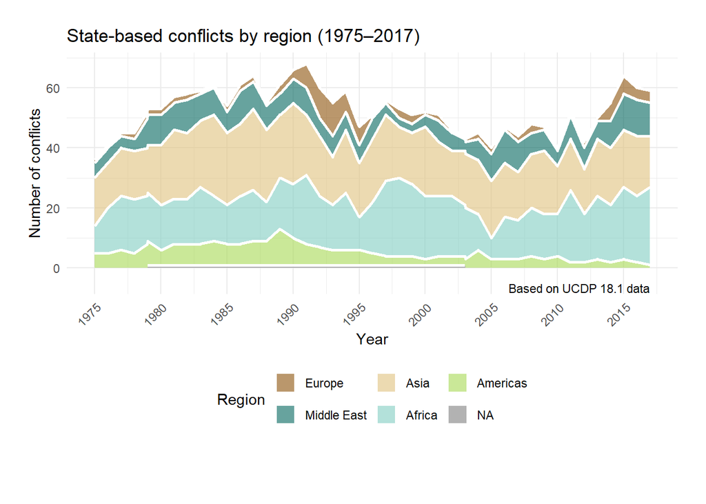

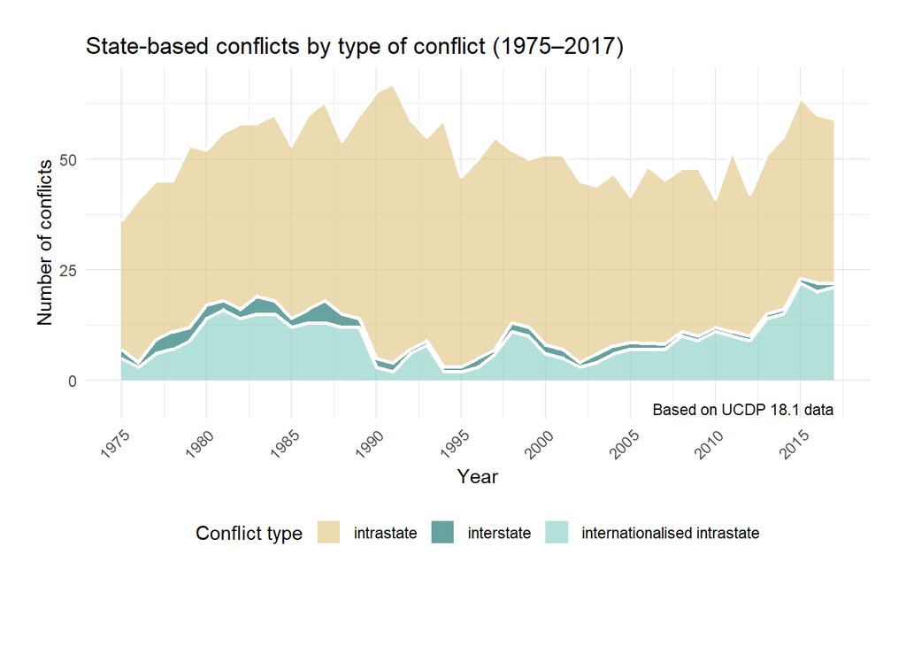

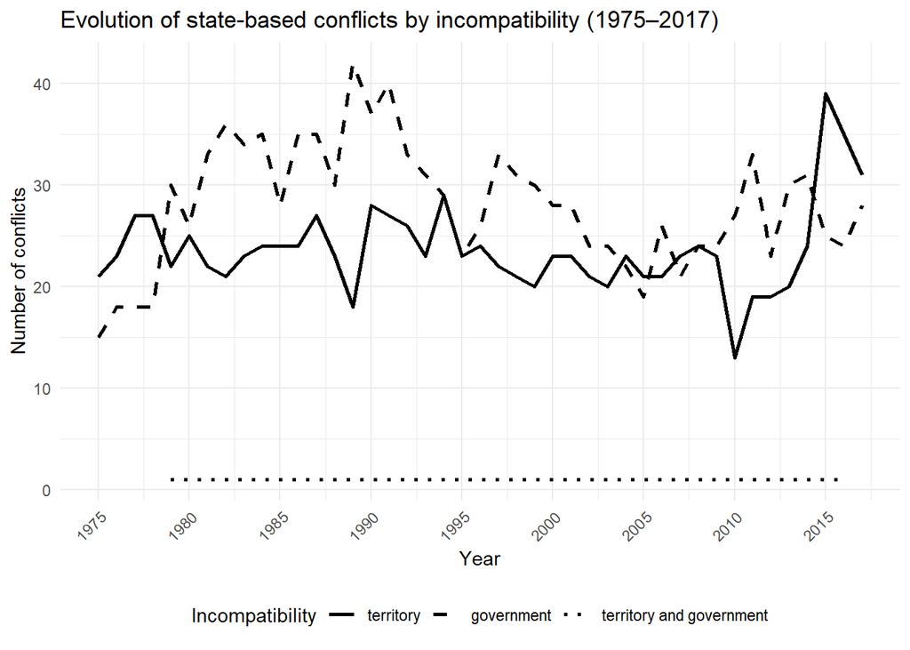

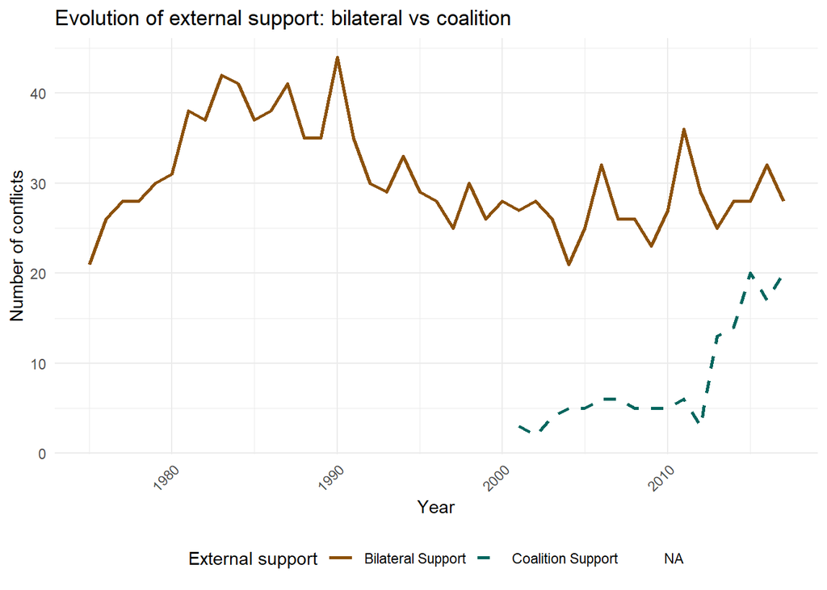

Statistical significance in the random effects linear regression models

| Independent Variable | Troop Support | Troop Presence | Access to Infrastructure | Weapons | Materiel and Statistics | Training and Expertise | Funding | Intelligence | Access to Territory |
| --- | --- | --- | --- | --- | --- | --- | --- | --- | --- |
| Intercept |  |  | 2.043 | 6.825 | 6.907 | 7.523 | 5.261 |  |  |
| Incompatibility |  |  |  |  |  |  |  | -2.986 (Government) |  |
| Type of conflict | 3.691 (Interstate); 162.037 (Internationalised intrastate) | -2.059 (Internationalised intrastate) | -2.716 (Internationalised intrastate) |  | 3.296 (Internationalised intrastate) | 3.053 (Internationalised intrastate) | 2.414 (Internationalised intrastate) | 2.170 (Internationalised intrastate) | -3.118 (Interstate) |
| Intensity |  | 2.697 (War) |  | 3.996 (War) | 2.899 (War) |  | 4.441 (War) |  |  |
| Region |  |  |  |  |  |  |  | 2.936 (Americas) | 2.214 (Middle East); 3.787 (Africa); 2.063 (Americas) |
| Duration |  |  |  |  |  |  | -2.612 |  |  |
| 9/11 |  |  |  | 2.625 (After) |  |  | 2.072 (After) | 7.519 (After) | -2.071 (after) |
| Cold War |  |  | 3.073 (After) | -5.280 (After) |  | -3.517 (After) | -2.516 (After) | 2.022 (After) |  |
| Coalition Support |  | 3.114 (Coalition) | 4.229 (Coalition) |  |  |  | -2.187 (Coalition) | 2.797 (Coalition) | 2.165 (Coalition) |
| N | 2330 | 1449 | 1449 | 1449 | 1449 | 1449 | 1449 | 1449 | 1449 |